# Foundations for statistical inference - Confidence intervals

Betsy Rosalen

March 18, 2018

## Sampling from Ames, Iowa

If you have access to data on an entire population, say the size of every house in Ames, Iowa, it’s straight forward to answer questions like, “How big is the typical house in Ames?” and “How much variation is there in sizes of houses?”. If you have access to only a sample of the population, as is often the case, the task becomes more complicated. What is your best guess for the typical size if you only know the sizes of several dozen houses? This sort of situation requires that you use your sample to make inference on what your population looks like.

## The data

In the previous lab, ``Sampling Distributions’’, we looked at the population data of houses from Ames, Iowa. Let’s start by loading that data set.

```r
load("more/ames.RData")
```

In this lab we’ll start with a simple random sample of size 60 from the population. Specifically, this is a simple random sample of size 60. Note that the data set has information on many housing variables, but for the first portion of the lab we’ll focus on the size of the house, represented by the variable `Gr.Liv.Area`.

```r
set.seed(300)
population <- ames$Gr.Liv.Area
samp <- sample(population, 60)
```

1. Describe the distribution of your sample. What would you say is the “typical” size within your sample? Also state precisely what you interpreted “typical” to mean.

   The sample distribution has a slight right skew with most houses falling around the 1500 mark, and a range from 520 to 2592. A ‘typical’ home in this sample is about 1361 square feet which is the median of the sample. I chose the median since the distribution is skewed and so the median is a better estimate of the ‘typical’ observation although in this case the mean and median are not too far apart so the mean of 1430 would also be a good estimate of the ‘typical’ home size.

   ```r
   summary(samp)
   ```

   ```
   ##    Min. 1st Qu.  Median    Mean 3rd Qu.    Max.
   ##     520    1050    1361    1430    1786    2592
   ```

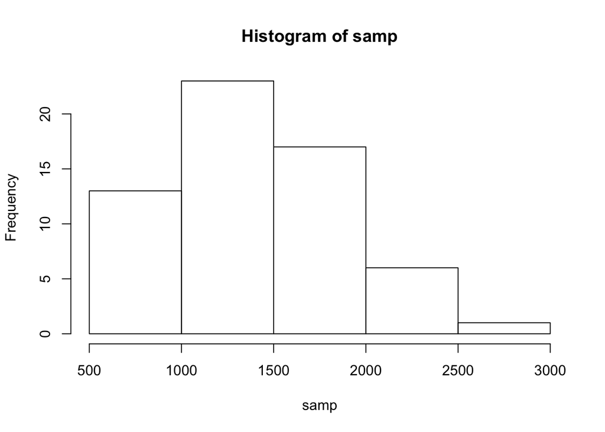

   ```r
   hist(samp)
   ```

2. Would you expect another student’s distribution to be identical to yours? Would you expect it to be similar? Why or why not?

   I would not expect another student’s sample to be identical to mine, but I would expect it to be similar. No two samples if taken at random would have identical statistics or distributions, but since most samples (if taken at random, and of sufficient size) would be good approximations of the population, I would expect them to be similar to each other.

## Confidence intervals

One of the most common ways to describe the typical or central value of a distribution is to use the mean. In this case we can calculate the mean of the sample using,

```r
sample_mean <- mean(samp)
```

Return for a moment to the question that first motivated this lab: based on this sample, what can we infer about the population? Based only on this single sample, the best estimate of the average living area of houses sold in Ames would be the sample mean, usually denoted as $\bar{x}$ (here we’re calling it `sample_mean`). That serves as a good *point estimate* but it would be useful to also communicate how uncertain we are of that estimate. This can be captured by using a *confidence interval*.

We can calculate a 95% confidence interval for a sample mean by adding and subtracting 1.96 standard errors to the point estimate (See Section 4.2.3 if you are unfamiliar with this formula).

```r
se <- sd(samp) / sqrt(60)
lower <- sample_mean - 1.96 * se
upper <- sample_mean + 1.96 * se
c(lower, upper)
```

```
## [1] 1311.072 1548.562
```

This is an important inference that we’ve just made: even though we don’t know what the full population looks like, we’re 95% confident that the true average size of houses in Ames lies between the values *lower* and *upper*. There are a few conditions that must be met for this interval to be valid.

3. For the confidence interval to be valid, the sample mean must be normally distributed and have standard error $\frac{s}{\sqrt{n}}$. What conditions must be met for this to be true?
   - The sample observations must be independent.
   - The sample size must be at least 30 but not larger than 10% of the population.
   - The population distribution cannot be strongly skewed.

## Confidence levels

4. What does “95% confidence” mean? If you’re not sure, see Section 4.2.2.

   ‘95% confidence’ means that we are 95% confident that our population parameter falls within the range specified by the confidence interval.

In this case we have the luxury of knowing the true population mean since we have data on the entire population. This value can be calculated using the following command:

```r
mean(population)
```

```
## [1] 1499.69
```

5. Does your confidence interval capture the true average size of houses in Ames? If you are working on this lab in a classroom, does your neighbor’s interval capture this value?

   Yes, my confidence interval does capture the true average size of houses in Ames.
6. Each student in your class should have gotten a slightly different confidence interval. What proportion of those intervals would you expect to capture the true population mean? Why? If you are working in this lab in a classroom, collect data on the intervals created by other students in the class and calculate the proportion of intervals that capture the true population mean.

   I would expect 95% of the confidence intervals to capture the true mean since we created our confidence interval at 95% by using $z^\star = 1.96$.

Using R, we’re going to recreate many samples to learn more about how sample means and confidence intervals vary from one sample to another. *Loops* come in handy here (If you are unfamiliar with loops, review the [Sampling Distribution Lab](http://htmlpreview.github.io/?https://github.com/andrewpbray/oiLabs/blob/master/sampling_distributions/sampling_distributions.html)).

Here is the rough outline:

- Obtain a random sample.
- Calculate and store the sample’s mean and standard deviation.
- Repeat steps (1) and (2) 50 times.
- Use these stored statistics to calculate many confidence intervals.

But before we do all of this, we need to first create empty vectors where we can save the means and standard deviations that will be calculated from each sample. And while we’re at it, let’s also store the desired sample size as `n`.

```r
samp_mean <- rep(NA, 50)
samp_sd <- rep(NA, 50)
n <- 60
```

Now we’re ready for the loop where we calculate the means and standard deviations of 50 random samples.

```r
set.seed(500)
for(i in 1:50){
  samp <- sample(population, n) # obtain a sample of size n = 60 from the population
  samp_mean[i] <- mean(samp)    # save sample mean in ith element of samp_mean
  samp_sd[i] <- sd(samp)        # save sample sd in ith element of samp_sd
}
```

Lastly, we construct the confidence intervals.

```r
lower_vector <- samp_mean - 1.96 * samp_sd / sqrt(n)
upper_vector <- samp_mean + 1.96 * samp_sd / sqrt(n)
```

Lower bounds of these 50 confidence intervals are stored in `lower_vector`, and the upper bounds are in `upper_vector`. Let’s view the first interval.

```r
c(lower_vector[1], upper_vector[1])
```

```
## [1] 1433.279 1714.987
```

## On your own

- Using the following function (which was downloaded with the data set), plot all intervals. What proportion of your confidence intervals include the true population mean? Is this proportion exactly equal to the confidence level? If not, explain why.

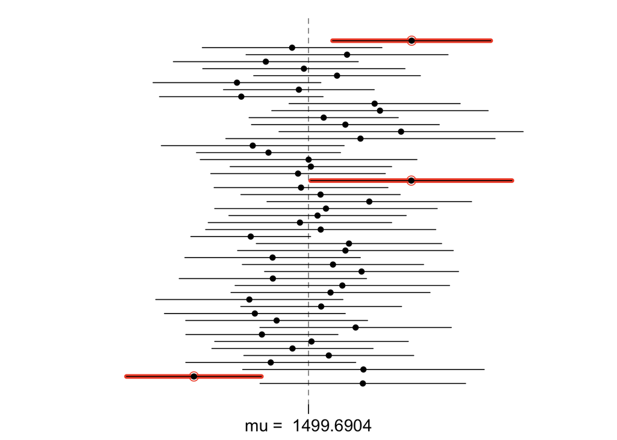

  ```r
  plot_ci(lower_vector, upper_vector, mean(population))
  ```

  47 out of 50 samples or 94% of my confidence intervals captured the population mean. This is not exactly equal to the 95% confidence interval but we would not expect it to be exactly equal to 95% since we are taking random samples and the samples are of a relatively small size compared to the size of the total population which has 2930 observations. And in fact it would be impossible to get exactly 95% accuracy with only 50 samples. No matter how many are accurate with 50 samples, you have to double the number to get the percent that are accurate, so the percent will always be an even number.
- Pick a confidence level of your choosing, provided it is not 95%. What is the appropriate critical value?

  For a 90% confidence interval you would use $z^\star = 1.65$ for a 99% confidence interval you would use $z^\star = 2.58$
- Calculate 50 confidence intervals at the confidence level you chose in the previous question. You do not need to obtain new samples, simply calculate new intervals based on the sample means and standard deviations you have already collected. Using the `plot_ci` function, plot all intervals and calculate the proportion of intervals that include the true population mean. How does this percentage compare to the confidence level selected for the intervals?

  My 90% confidence interval plot returned exactly 90% accurate confidence intervals and my 99% confidence intervals are 98% accurate.

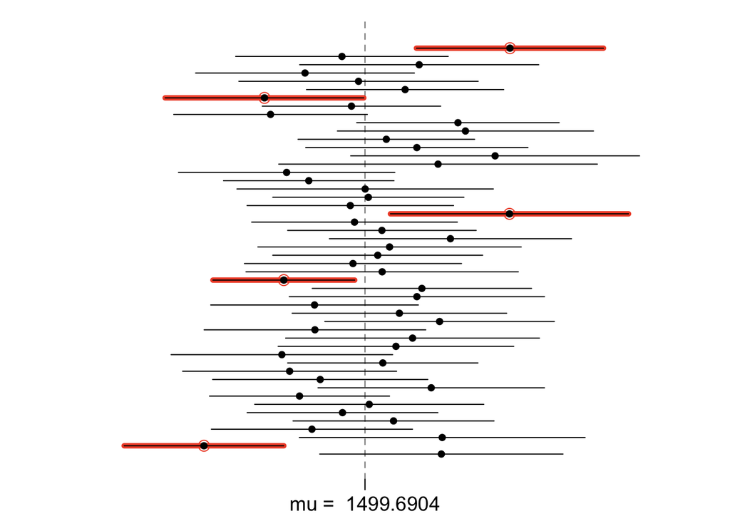

  ```r
  lower_vector90 <- samp_mean - 1.65 * samp_sd / sqrt(n)
  upper_vector90 <- samp_mean + 1.65 * samp_sd / sqrt(n)
  plot_ci(lower_vector90, upper_vector90, mean(population))
  ```

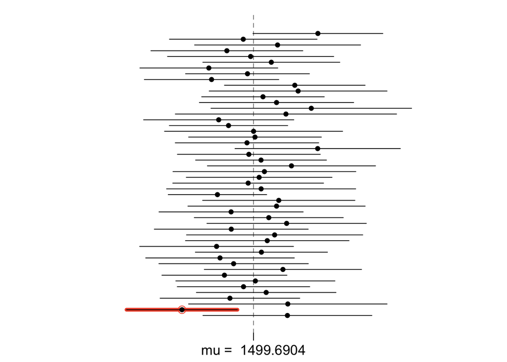

  ```r
  lower_vector99 <- samp_mean - 2.58 * samp_sd / sqrt(n)
  upper_vector99 <- samp_mean + 2.58 * samp_sd / sqrt(n)
  plot_ci(lower_vector99, upper_vector99, mean(population))
  ```

This is a product of OpenIntro that is released under a [Creative Commons Attribution-ShareAlike 3.0 Unported](http://creativecommons.org/licenses/by-sa/3.0). This lab was written for OpenIntro by Andrew Bray and Mine Çetinkaya-Rundel.